# **Addition Insights - Companies to Watch Newsletter**

April 21, 2022

[figure not shown]

## **Tiggy**

**Company:** Tiggy  
**Country (Operating):** 1231 Pacific Boulevard, Office 129, Vancouver, British Columbia V6Z 0E2, Canada  
**Founded Date:** January 01, 2021  
**Homepage:** https://gotiggy.com  
**Current Headcount:** 101  
**Lifetime Funding:** $6,350,000  
**Number of Funding Rounds:** 3  
**Investors:** TA Ventures, FJ Labs, Inovia Capital, Myelin VC, Oscar Hartmann, Global Founders Capital, Anders Holch Povlsen, Fores Ventures, Redbox Ventures, Smart Partnership Capital - Venture Capital Fund  
**Most Recent Funding:** EARLY STAGE VC - April 01, 2022  
**Sectors:** E-Commerce, Consumer Software Services  
**Description:**

### **Headcount**

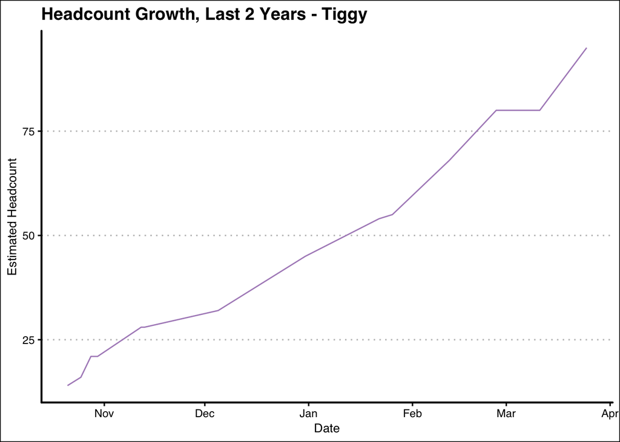

## **BHub**

### **Headcount**

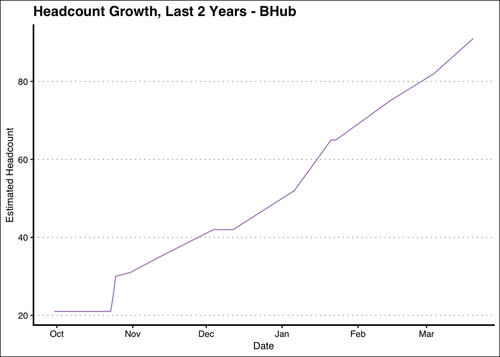

## **Treeline Biosciences**

**Company:** Treeline Biosciences  
**Country (Operating):** Stamford, Connecticut, United States  
**Founded Date:** January 01, 2021  
**Homepage:** https://treeline.bio  
**Current Headcount:** 88  
**Lifetime Funding:** $735,000,000  
**Number of Funding Rounds:** 1  
**Investors:** GV, Aisling Capital, ARCH Venture Partners, Casdin Capital, LLC, OrbiMed, Ajax Health, Access Industries  
**Most Recent Funding:** SERIES A - April 27, 2021  
**Sectors:** Biotechnology, Health / Wellness, Chemical / Life Sciences  
**Description:** We aspire to build transformative precision medicines for patients with cancer and other serious conditions.

### **Headcount**

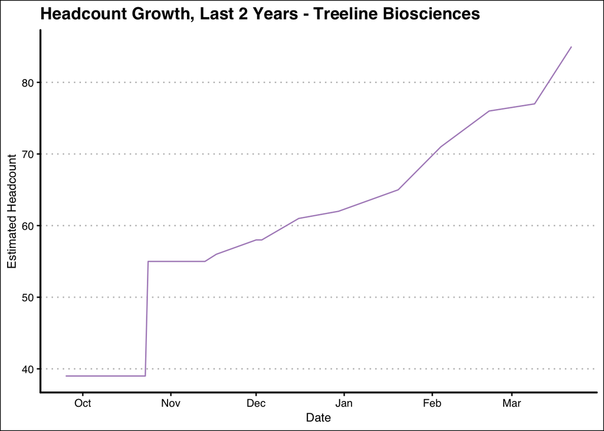

## **Circulo Health**

**Company:** Circulo Health  
**Country (Operating):** 629 North High Street, 6th Floor, Columbus, OH 43215, United States  
**Founded Date:** January 01, 2020  
**Homepage:** http://circulohealth.com  
**Current Headcount:** 145  
**Lifetime Funding:** $50,000,000  
**Number of Funding Rounds:** 1  
**Investors:** Drive Capital, Oak HC/FT, SVB Capital, General Catalyst, Silicon Valley Bank  
**Most Recent Funding:** SERIES A - February 19, 2021  
**Sectors:** Financial Technology, Financial / Insurance Services, Health / Wellness  
**Description:**

### **Headcount**

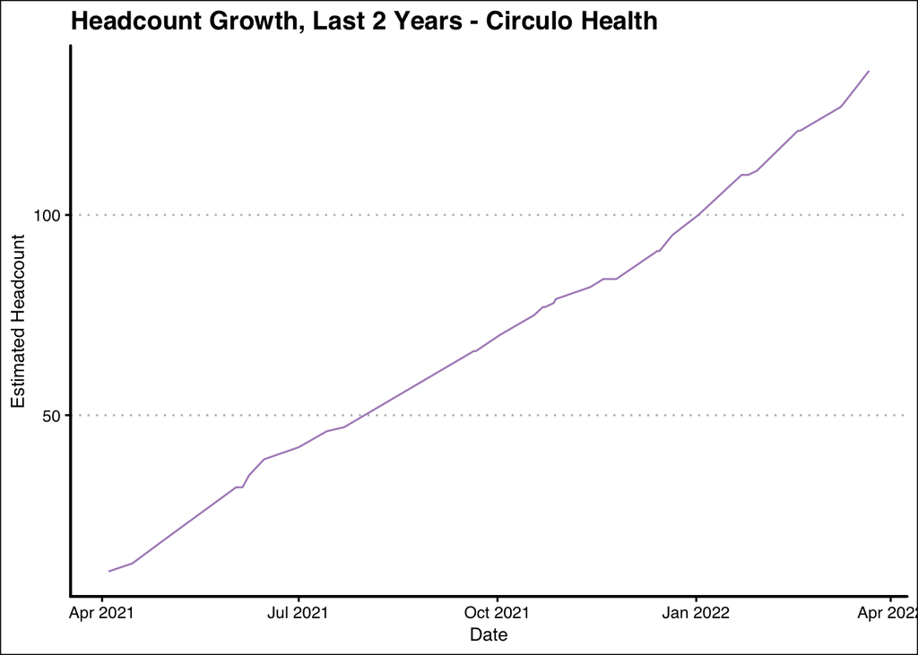

## **Draftea**

**Company:** Draftea  
**Country (Operating):** Mexico CIty, Mexico  
**Founded Date:** January 01, 2021  
**Homepage:** https://draftea.com  
**Current Headcount:** 43  
**Lifetime Funding:** $17,200,000  
**Number of Funding Rounds:** 2  
**Investors:** Bullpen Capital, KASZEK, MANTIS Venture Capital, Courtside Ventures, Thirty Five Ventures, Odell Beckham, Arrive, NNS Group, Sequoia Capital, NSS Advisors, Nigel Eccles, Pau Gasol, Iker Casillas, Odell Beckham Jr, César Azpilicueta, Travis Kelce  
**Most Recent Funding:** SEED - March 21, 2022  
**Sectors:** Sports  
**Description:**

### **Headcount**

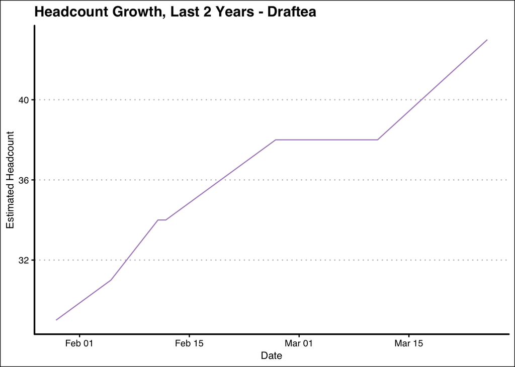

## **SIRKA**

**Company:** SIRKA  
**Country (Operating):** Jakarta, Jakarta Raya, Indonesia  
**Founded Date:** January 01, 2021  
**Homepage:** https://sirka.io  
**Current Headcount:** 65  
**Lifetime Funding:** $2,600,000  
**Number of Funding Rounds:** 1  
**Investors:** Goodwater Capital, AC Ventures, WaveMaker, Inc., Sequoia Capital India, Y Combinator, TIM LEE MINISTRIES, Sequoia Capital, Timothy Lee, Maudy Ayunda  
**Most Recent Funding:** SEED - February 07, 2022  
**Sectors:** Launch, S21, Health / Wellness, Consumer Software Services, Health / Nutritional Science  
**Description:** SIRKA | Diet Coaching App Wellness Redefined Eat Well. Exercise Smart. Live Empowered Find us on IG @sirka.io

### **Headcount**

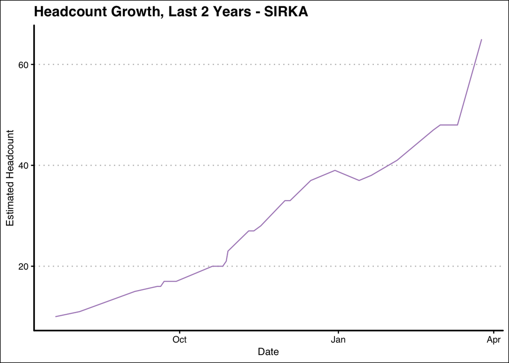

## **Zolve**

**Company:** Zolve  
**Country (Operating):** San Francisco, CA, United States  
**Founded Date:** January 01, 2020  
**Homepage:** https://zolve.com  
**Current Headcount:** 161  
**Lifetime Funding:** $55,065,805  
**Number of Funding Rounds:** 2  
**Investors:** Indian Angel Network, Lightspeed Venture Partners, Alkeon Capital Management, Accel, Founder Collective, Lightspeed, Blume Ventures, DST Global, Richmond View Ventures GmbH, Tiger Global Management, Ashish Gupta, Kunal Shah, Greg Kidd, Rahul Mehta, Rahul Kishore  
**Most Recent Funding:** SERIES A - October 26, 2021  
**Sectors:** Financial Technology, Financial / Insurance Services  
**Description:**

### **Headcount**

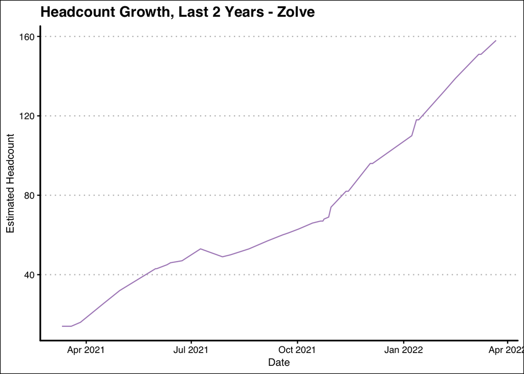

## **Bobbie**

**Company:** Bobbie  
**Country (Operating):** 1500 Castro Street, San Francisco, CA 94114, United States  
**Founded Date:** January 01, 2018  
**Homepage:** https://hibobbie.com  
**Current Headcount:** 79  
**Lifetime Funding:** $56,500,000  
**Number of Funding Rounds:** 5  
**Investors:** Bolt, Wave Capital, NextView Ventures, Lakehouse Ventures, Precursor Ventures, VMG Partners, Park West Asset Management LLC, 1st Course Capital, Offline Ventures, DAVE MORIN, AirAngels  
**Most Recent Funding:** SERIES B - February 10, 2022  
**Sectors:** Consumer Goods, Restaurant / Food / Beverage, E-Commerce, Ag / Food Tech  
**Description:**

### **Headcount**

[figure not shown]

### **Traffic**

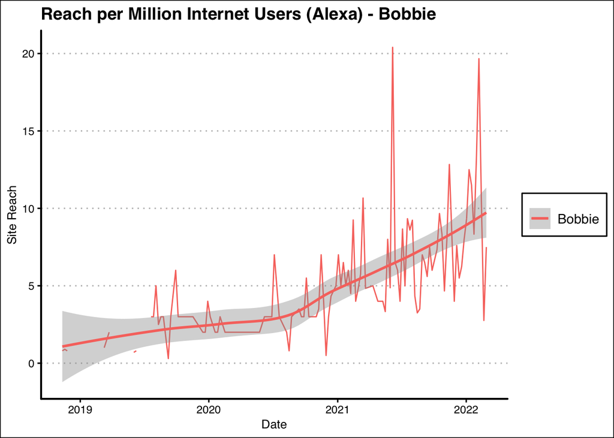

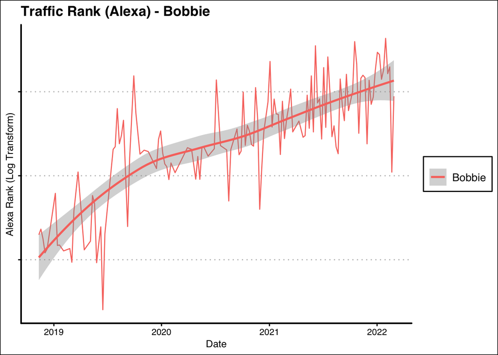

### **Revenue**

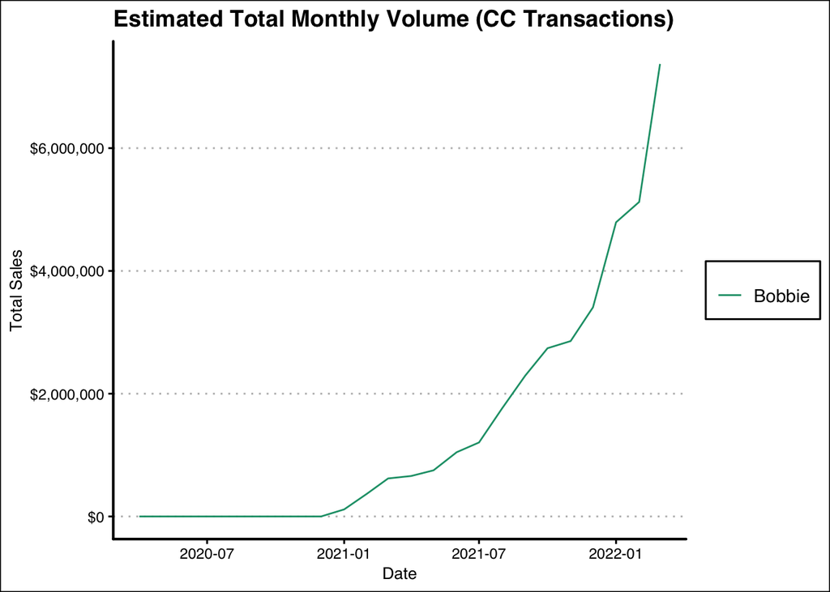

## **Headway**

### **Headcount**

[figure not shown]

### **Traffic**

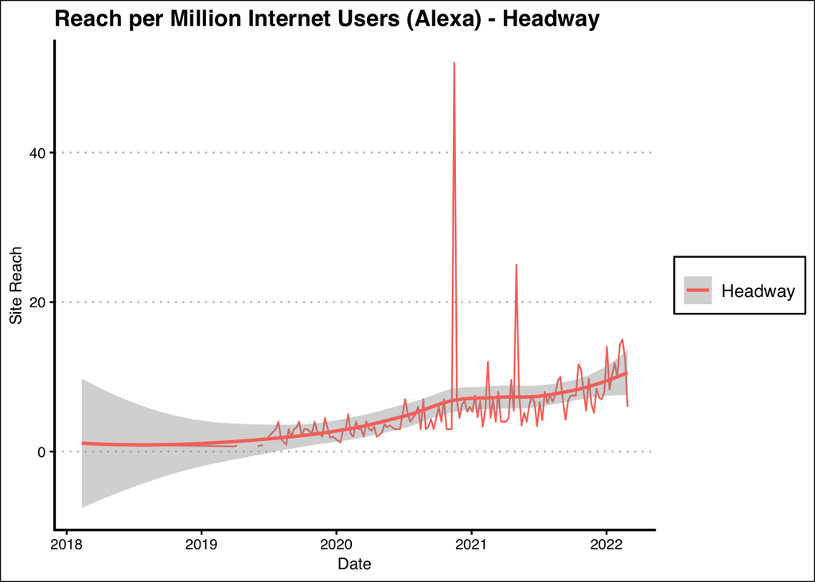

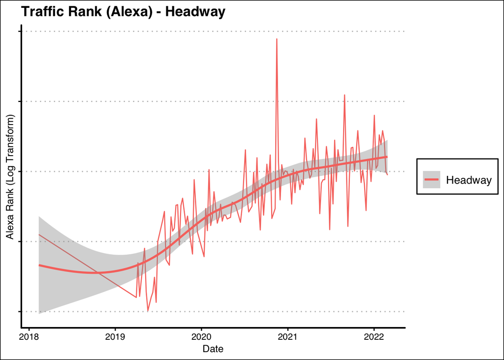

### **Revenue**

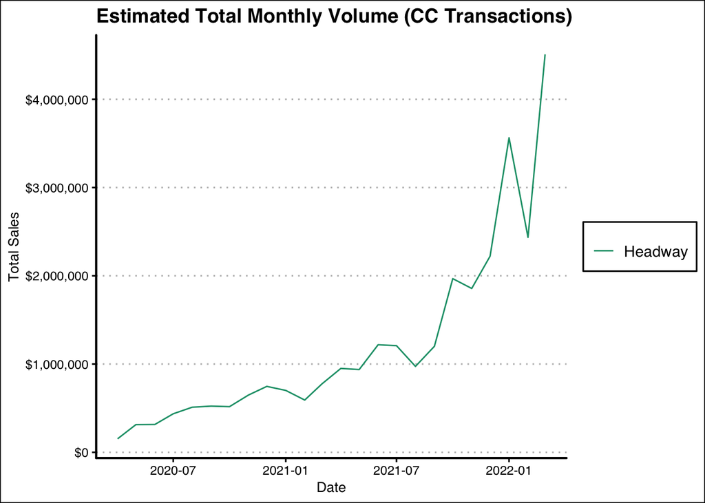

## **CoinTracker**

**Company:** CoinTracker  
**Country (Operating):** 2093 Philadelphia Pike, Suite 2046, Claymont, DE 19703, United States  
**Founded Date:** January 01, 2017  
**Homepage:** https://cointracker.io  
**Current Headcount:** 49  
**Lifetime Funding:** $102,120,000  
**Number of Funding Rounds:** 3  
**Investors:** Accel, Kindred Ventures, Seven Seven Six 7️⃣7️⃣6️⃣, Garry Tan, General Catalyst, Balaji Srinivasan, Gokul Rajaram, Redwood Studio, Alexis Ohanian Sr., Y Combinator, Stacks, Intuit, Coinbase, Jesse Clayburgh, Baris Gultekin, Steve Jang, Initialized Capital, Coinbase Ventures, Kraken Ventures, Juan Batiz-Benet, Paul Buchheit, Jeremy Liew, Balaji S., Juan Benet, Nick Raushenbush, Claire Hughes Johnson  
**Most Recent Funding:** SERIES A - February 09, 2022  
**Sectors:** Financial Technology, Financial / Insurance Services, Blockchain / Crypto  
**Description:**

### **Headcount**

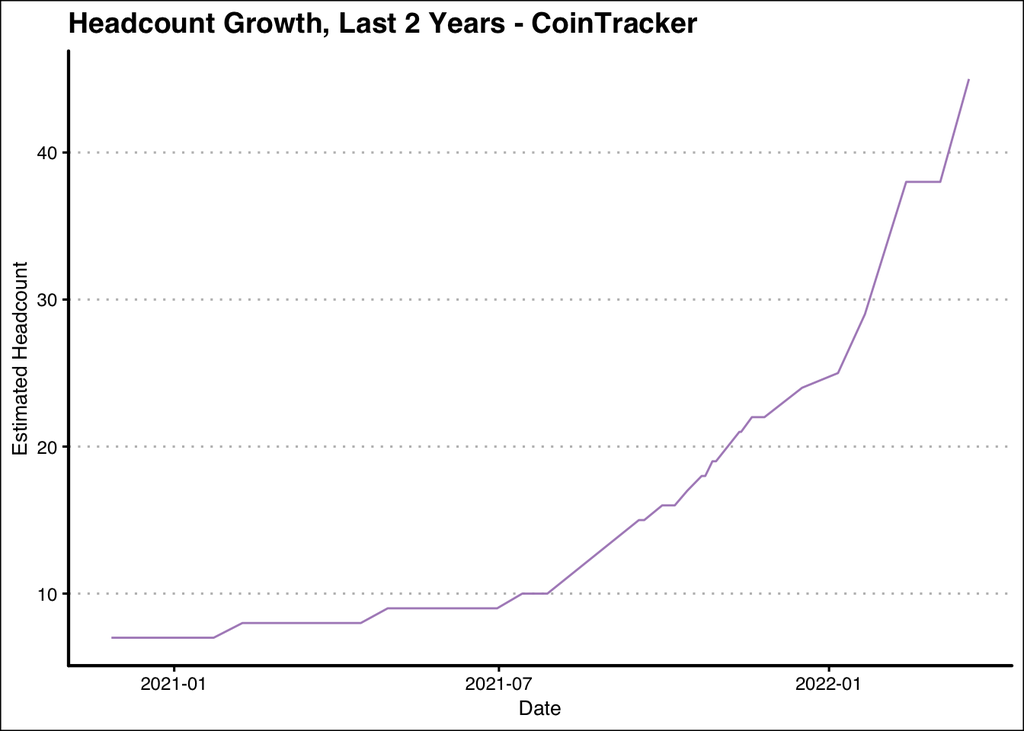

### **Traffic**

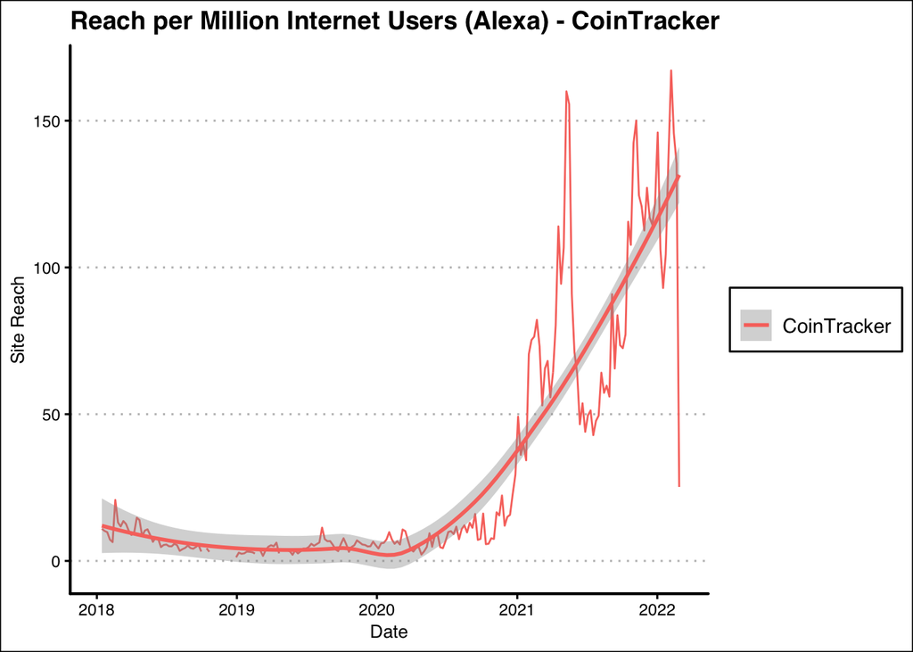

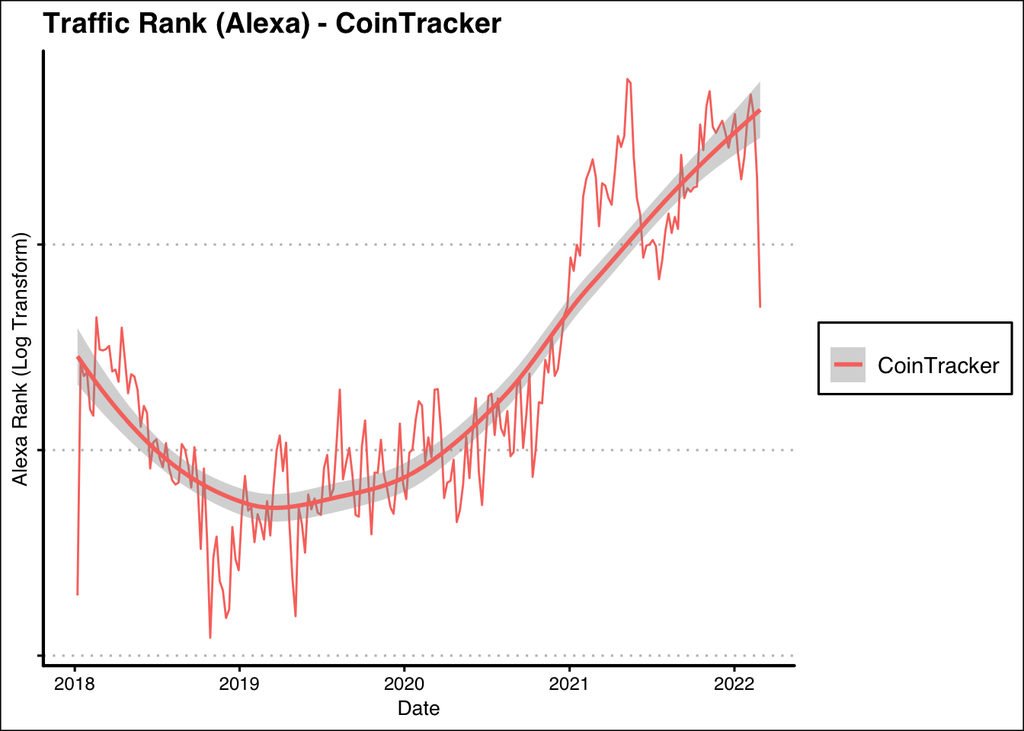

### **Revenue**

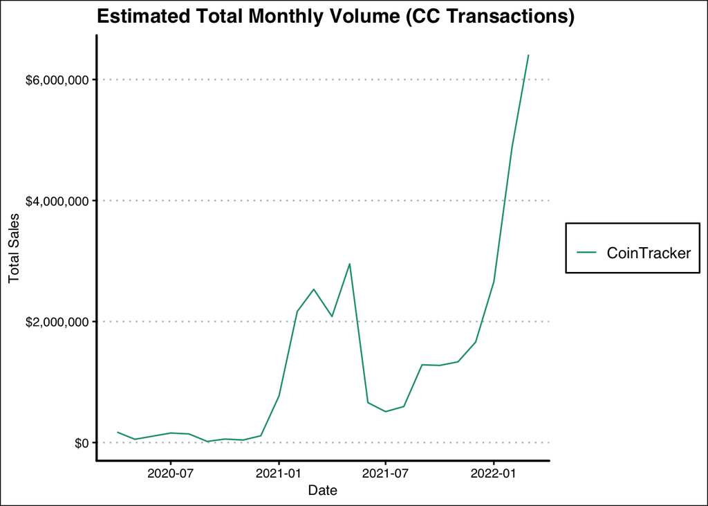